# DATA 605 - Final

### Boxcox transformation and comparative plots

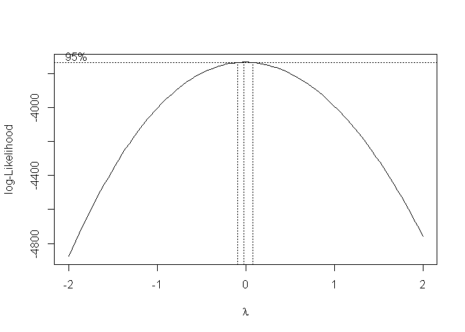

```r
slm = lm(Y~X) #Create simple regression model
bc = boxcox(slm) # Find lambdas
```

```r
transformed_model = as.data.frame(bc)
lambdaM = bc$x[which.max(bc$y)] # Get lambda for model optimization; though we're not using it...Objective here is to transform both variables by themselves...Just showcasing
lambdaX = BoxCox.lambda(X) # lambda for X
lambdaY = BoxCox.lambda(Y) # lambda for Y
```

Lambdas are between -2 and 2 (-0.020202), boxcox transformation is appropriate.

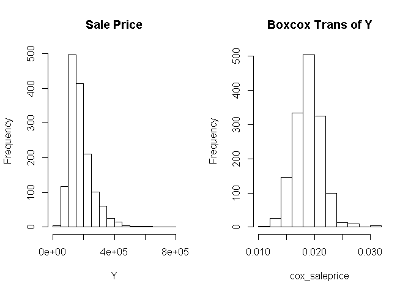

```r
cox_saleprice =  Y^lambdaY
cox_rooms = X^lambdaX
par(mfrow=c(1,2))
hist(Y,main="Sale Price")
hist(cox_saleprice,main="Boxcox Trans of Y")
```

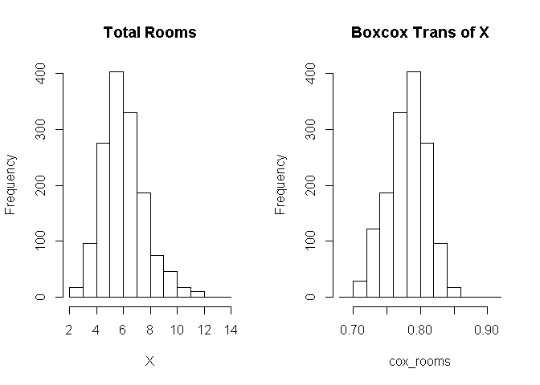

```r
par(mfrow=c(1,2))
hist(X,main='Total Rooms')
hist(cox_rooms,main='Boxcox Trans of X')
```

## ————————> Section 3

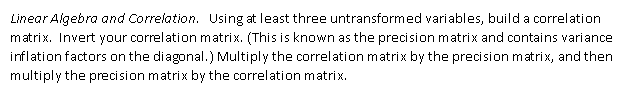

### 3 variables = Garage Area, Total Rooms Abv Grade, Sale Price

```r
adf = data.frame(GarageArea=df$GarageArea,Rooms=df$TotRmsAbvGrd,SalePrice=df$SalePrice)
correlationMatrix = cor(adf)
correlationMatrix
```

```
##            GarageArea     Rooms SalePrice
## GarageArea  1.0000000 0.3378221 0.6234314
## Rooms       0.3378221 1.0000000 0.5337232
## SalePrice   0.6234314 0.5337232 1.0000000
```

```r
invertedCorrelationMatrix = solve(correlationMatrix)
invertedCorrelationMatrix
```

```
##             GarageArea       Rooms  SalePrice
## GarageArea  1.63586571 -0.01162571 -1.0136452
## Rooms      -0.01162571  1.39841102 -0.7391165
## SalePrice  -1.01364520 -0.73911651  2.0264219
```

```r
round(correlationMatrix%*%invertedCorrelationMatrix,0)
```

```
##            GarageArea Rooms SalePrice
## GarageArea          1     0         0
## Rooms               0     1         0
## SalePrice           0     0         1
```

```r
round(invertedCorrelationMatrix%*%correlationMatrix,0)
```

```
##            GarageArea Rooms SalePrice
## GarageArea          1     0         0
## Rooms               0     1         0
## SalePrice           0     0         1
```

Ladies and gentlemen, the identity matrix!

## ————————> Section 4

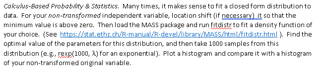

As seen before; total rooms variable is between 2 & 14. No location shift is necessary

I believe the total rooms variable looks similar to a lognormal distribution. Let us see if I’m right.

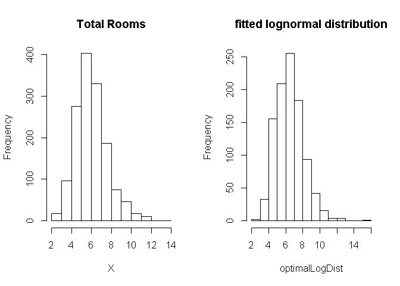

```r
aFit = fitdistr(X,'log-normal')
optimalLogDist = rlnorm(1000,meanlog = aFit$estimate[[1]],sdlog = aFit$estimate[[2]])
par(mfrow=c(1,2))
hist(X,main='Total Rooms')
hist(optimalLogDist,main='fitted lognormal distribution')
```

These histograms are are very similar, perhaps a boxplot might help interpret the differences.

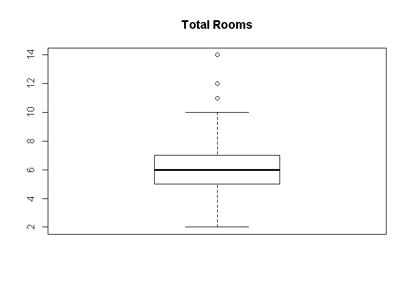

```r
boxplot(X,main='Total Rooms')
```

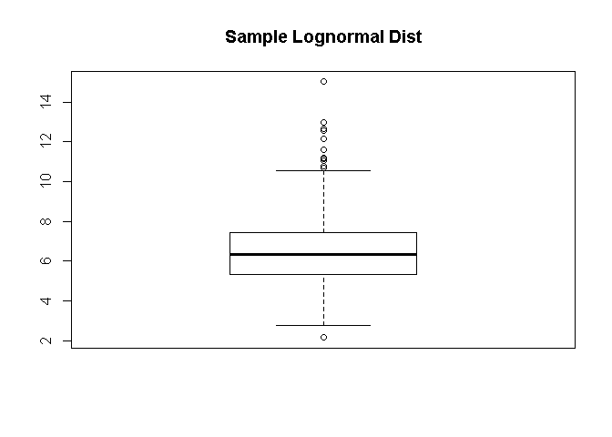

```r
boxplot(optimalLogDist,main='Sample Lognormal Dist')
```

Looks like the lognormal distribution, with optimal parameters produces many high valued outliers (as expected of lognormal to have a greater right skew) and raises the 1st & 3rd quartiles + median. While keeping the distance between max and min relatively the same.